# The LA City Equity Index

Proposed Indicators and Framework by the Make LA Whole Coalition

Analysis by Catalyst California

16 September, 2026

# Overview

The following includes recommended indicators for the Los Angeles City Equity Index (the Index). These recommendations are informed by the MLAW Coalition’s community survey, partner feedback, Catalyst California’s research and analysis of available data, and current indicators under consideration by the City.

The proposed Index is structured around four domains each intended to illustrate what an equitable city should look like for all people.

**Safe Environments**: LA City residents experience safe environments with safety from pollution, traffic injuries, and harmful policing. **Economy and Opportunity**: LA City residents have the opportunity to equitably engage in the economy. **Democracy and Power**: LA City residents have the opportunity to equitably participate and influence democracy. **Longevity and Vitality**: LA City residents live with with freedom from disease and illness and have the ability to access resources that increase community wellness.

The proposed **LA City Equity Index** represents the average across these four domains. It provides one summarized measure of need for each ZIP Code in LA City.

There are two to five **indicators** included within each domain. A race composite measure is also included in each domain to firmly acknowledge the deep-seated role of racism in shaping opportunities and outcomes in the city. This race composite measure takes into account the share of the population in each ZIP Code that identifies as Asian, Black, Latine, American Indian and Alaska Native (AIAN), or Native Hawaiian and Pacific Islander (NHPI).

In sum, 15 indicators are included in the Index. Over 20 indicators were originally considered for inclusion. Indicators were narrowed based on data availability, community surveys, partner feedback, and data availability. The following page details the analysis done for the indicators studied for the Index. It includes individual maps for every indicator by domain and graphics illustrating the relationship, or correlation, between indicators in each domain and race.

Please visit our [recommendations page](https://github.com/catalystcalifornia/mlaw/blob/main/LA%20City%20Equity%20Index%20Recommendations.pdf) to read our full recommendations to the City and see our [GitHub repository](https://github.com/catalystcalifornia/mlaw/blob/main/README.md) to view our full methodology.

# Index Results

We first present the final draft **Index** map showing level of need by ZIP Code in LA City. The Index represents the average need across the four index domains. The darker purple areas represent areas in the city with higher need whereas lighter purple areas have relatively lower need.

## Equity Index

[interactive chart not shown]

## Domain Indices

In addition to the **Index** score, each ZIP Code has four scores that show level of need by domain. Domain scores are the average need across the indicators included in each domain. The darker purple areas show areas in the city with relatively higher need in that domain.

### Safe Environments

**What this domain means:** LA City residents experience safe environments with safety from pollution, traffic injuries, and harmful policing.

**What it includes:** Race Composite Score (Black, Latine, AIAN, NHPI, Asian); Particulate Matter (PM) 2.5; Proximity to Hazardous Waste Facilities; Pedestrian and Bicyclist Fatalities and Injuries; Arrests; Hospitalizations for Gun Injuries

[interactive chart not shown]

### Economy and Opportunity

**What this domain means:** LA City residents have the opportunity to equitably engage in the economy.

**What it includes:** Race Composite Score (Black, Latine, AIAN, NHPI, Asian); Early Childhood Education (ECE) Enrollment; Rent Burden; Evictions; Per Capita Income

[interactive chart not shown]

### Democracy and Power

**What this domain means:** LA City residents have the opportunity to equitably participate and influence democracy.

**What it includes:** Race Composite Score (Black, Latine, AIAN, NHPI, Asian); Limited English Speaking Households; Voter Turnout for the 2022 General Election

[interactive chart not shown]

### Longevity and Vitality

**What this domain means:** LA City residents live with freedom from disease and illness and have the ability to access resources that increase community wellness.

**What it includes:** Race Composite Score (Black, Latine, AIAN, NHPI, Asian); Diabetes Hospitalizations; Impervious Land Cover; Health and Mental Health Care Services Access; Grocery Store Access

[interactive chart not shown]

# Indicator Maps

We separately visualize the indicators included in each domain to verify if the indicator and method used accurately measures need across the city and ground-truth trends. We also test each indicator for its relationship to race and other indicators in the same domain.

## Domain 1: Safe Environments

**What this domain means:** LA City residents experience safe environments with safety from pollution, traffic injuries, and harmful policing.

### Maps

The maps show ZIP Codes by *lowest to highest rates* for each indicator. Darker purple areas show areas with *higher rates* for that particular indicator whereas lighter purple areas show areas with *lower rates* for that indicator. Darker purple means greater need in challenge-based indicators (e.g., pollution burden), but lower need in asset-based indicators (e.g., per capita income).

#### PM 2.5

[interactive chart not shown]

Data Source: CalEnviroScreen 4.0, 2021.

#### Proximity to Hazardous Waste Facilities

[interactive chart not shown]

Data Source: CalEnviroScreen 4.0, 2021.

#### Pedestrian and Bicyclist Fatalities and Injuries

[interactive chart not shown]

Data Source: California Statewide Integrated Traffic Records System (SWITRS), 2022.

#### Arrests

[interactive chart not shown]

Data Source: Los Angeles Police Department, Arrest Data, 2022.

#### Hospitalizations for Gun Injuries

[interactive chart not shown]

Data Source: California Department of Health Care Access and Information, Patient Discharge Data, 2017-2021.

### Correlations

This matrix shows the relationship between every indicator in the domain. Larger and darker blue circles represent indicators with greater positive relationships–meaning as one rate goes up, so does the other. Larger and darker red circles show which indicators have a negative relationship–meaning as a measure for one indicator goes up, the other goes down. Many indicators are correlated with at least one BIPOC group, meaning as need in an area goes up, so does the rate of BIPOC people in at least one group. Inversely, many indicators that show need are inversely correlated with the share of White people. Blank squares on the correlation matrix indicate that there is not a significant relationship between the indicators.

In this domain, we recommend including PM 2.5 and proximity to hazards to measure pollution burden given their stronger correlations with different BIPOC groups over other pollution burden indicators explored.

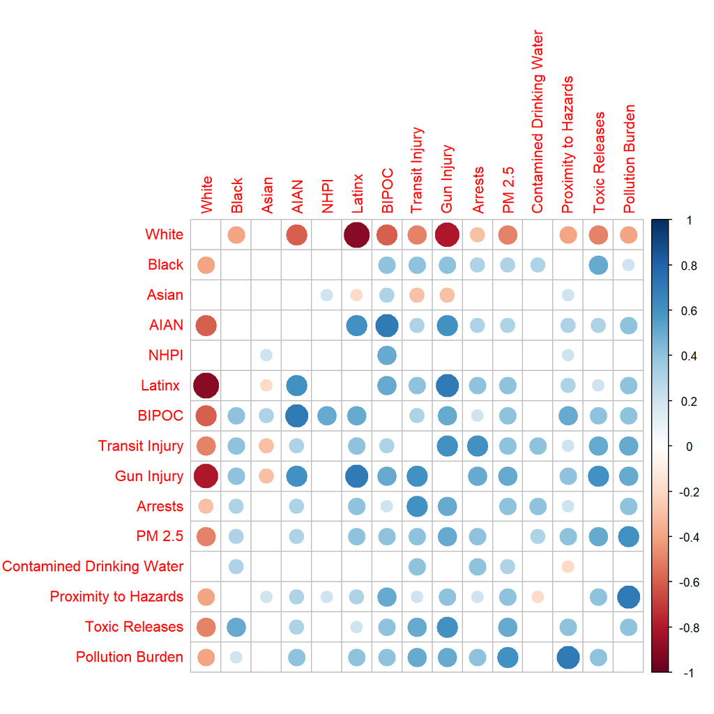

## Domain 2: Economy and Opportunity

**What this domain means:** LA City residents have the opportunity to equitably engage in the economy.

### Maps

The maps show ZIP Codes by *lowest to highest rates* for each indicator. Darker purple areas show areas with *higher rates* for that particular indicator whereas lighter purple areas show areas with *lower rates* for that indicator. Darker purple means greater need in challenge-based indicators (e.g., rent burden), but lower need in asset-based indicators (e.g., per capita income).

#### Early Childhood Education (ECE) Enrollment

[interactive chart not shown]

Data Source: American Institute for Research, Early Learning Needs Assessment Tool, 2020. California Child Care Resource & Referral Network, 2021.

#### Rent Burden

[interactive chart not shown]

Data Source: U.S. Census Bureau, American Community Survey, B25070, 2018-2022.

#### Eviction Notices

[interactive chart not shown]

Data Source: LA City Control, Eviction Notices February-December 2023. U.S. Census Bureau, American Community Survey, 5-Year Estimates, Table B25003, 2018-2022.

#### Per Capita Income

[interactive chart not shown]

Data Source: U.S. Census Bureau, American Community Survey, B19301, 2018-2022.

### Correlations

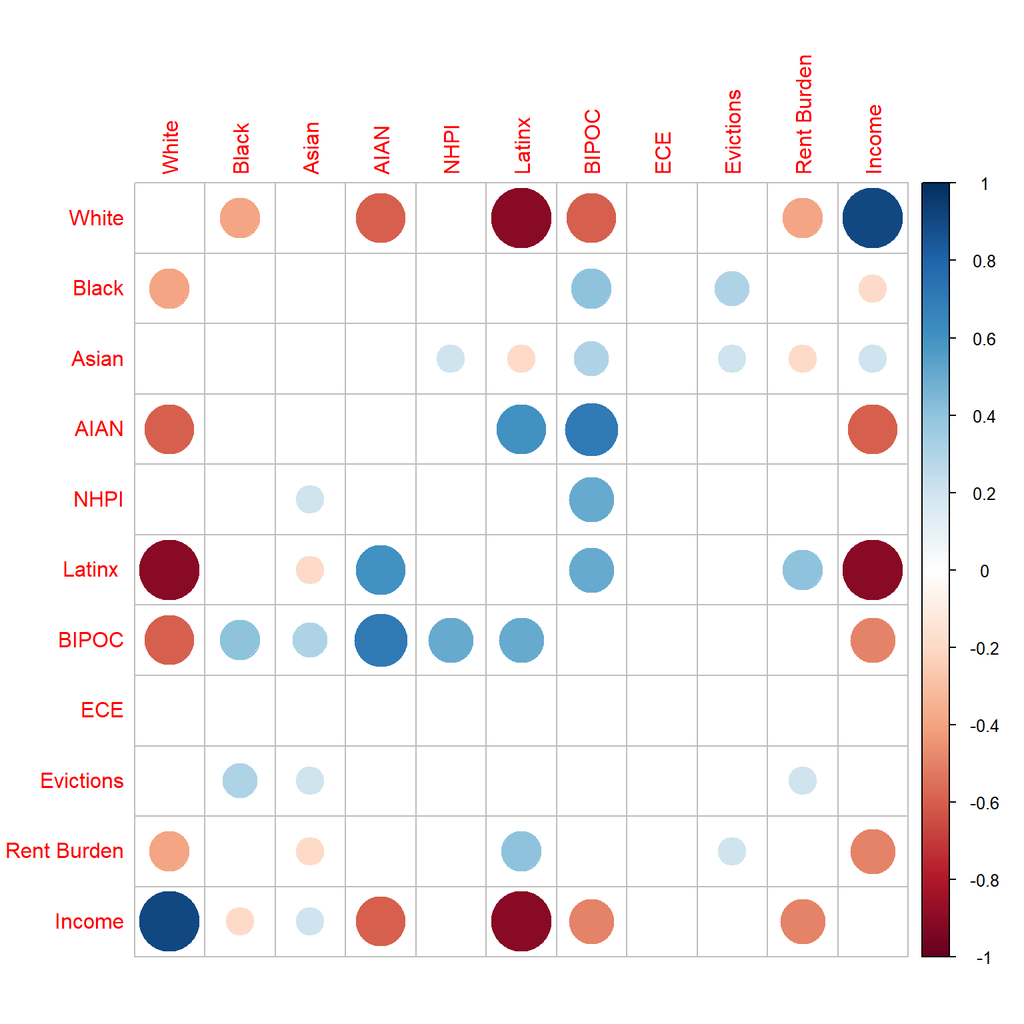

## Domain 3: Democracy and Power

**What this domain means:** LA City residents will have the opportunity to equitably participate and influence democracy.

### Maps

The maps show ZIP Codes by *lowest to highest rates* for each indicator. Darker purple areas show areas with *higher rates* for that particular indicator whereas lighter purple areas show areas with *lower rates* for that indicator. Darker purple means greater need in challenge-based indicators (e.g., pollution burden), but lower need in asset-based indicators (e.g., voter turnout).

#### Limited English Speaking Households

[interactive chart not shown]

Data Source: U.S. Census Bureau, American Community Survey, S1602, 2018-2022.

#### Voter Turnout

[interactive chart not shown]

Data Source: Los Angeles County Registrar-Recorder/County Clerk, General Election Results, November 2022. Statewide Redistricting Database, General Election Geographic Data, Consolidated Precincts, 2022.

### Correlations

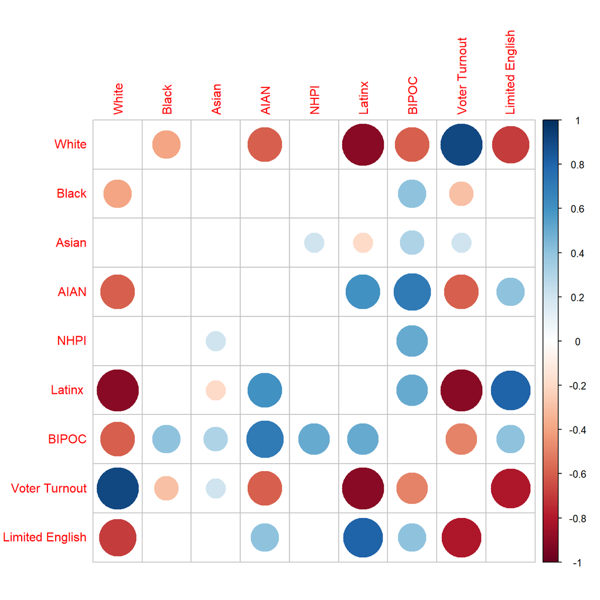

## Domain 4: Longevity and Vitality

**What this domain means:** LA City residents will live with with freedom from disease and illness, and have the ability to access resources that increase community wellness.

### Maps

The maps show ZIP Codes by *lowest to highest rates* for each indicator. Darker purple areas show areas with *higher rates* for that particular indicator whereas lighter purple areas show areas with *lower rates* for that indicator. Darker purple means greater need in challenge-based indicators (e.g., diabetes hospitalizations), but lower need in asset-based indicators (e.g., health/mental health care services).

#### Diabetes Hospitalizations

[interactive chart not shown]

Data Source: California Department of Health Care Access and Information, Patient Discharge Data, 2017-2021.

#### Impervious Land Cover

[interactive chart not shown]

Data Source: Earth Resources Observation and Science Center, National Land Cover Database, 2021.

#### Health/Mental Health Care Services

[interactive chart not shown]

Data Source: IRS Exempt Organizations Business Master File, 2024.

#### Grocery Store Access

[interactive chart not shown]

Data Source: Calculations based on USDA Food and Nutrition Service, SNAP Retailer Location Data, 2024.

### Correlations

This matrix shows the relationship between every indicator in the domain. Larger and darker blue circles represent indicators with greater positive relationships–meaning as one rate goes up, so does the other. Larger and darker red circles show which indicators have a negative relationship–meaning as a measure for one indicator goes up, the other goes down. Blank squares on the correlation matrix indicate that there is not a significant relationship between the indicators.

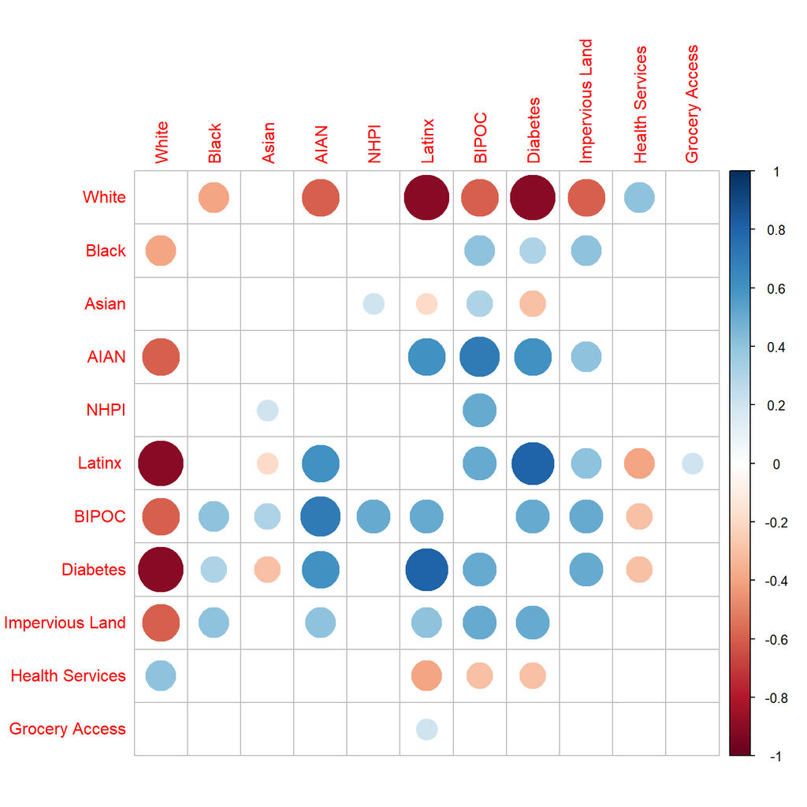

# Partners

This work would not have been possible without the collaboration and invaluable insights provided by our partners in the MLAW Coalition. MLAW Coalition partners include: Community Coalition, Inner City Struggle, Black Women for Wellness, Brotherhood Crusade, SEIU 99, and SEIU 2015.